# Final Project - Milk Quality

Eleanor Li

2022-11-23

## Introduction

Milk as a common dairy product consumed and loved by a lot of people, can provide us plenty of nitration. However it can also cause concerns and bring illness to human body when the quality of the milk goes bad. The aim of this project is to build a machine learning model to predict the quality of milk using classification. The dataset contains 7 variables that will affect milk quality: pH, Temperature, Taste, Odor, Fat, Turbidity, and Color. We will first analyze the variables, use the dataset to train our model, find the best model and finally use the testing set to test whether it could give us good predictions. data source: https://www.kaggle.com/datasets/cpluzshrijayan/milkquality

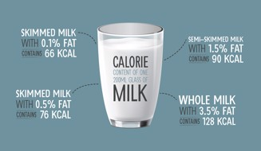

```r
knitr::include_graphics("C:/Users/Eleanor/Downloads/milk_5.jpg")
```

## Loading Environment

```r
library(tidymodels)
library(tidyverse)
```

```r
library(dplyr)
library(ggplot2)
library(janitor)
library(corrplot)
library(corrr)
library(mod)
library(randomForest)
library(vip)
library(ranger)
library(xgboost)
library(klaR)
library(MASS)
tidymodels_prefer()
```

## Exploratory Data Analysis

### Loading and Processing Data

```r
milk<-read.csv('C:/Users/Eleanor/Desktop/data/unprocessed/milknew.csv')

milk<-milk %>%
  clean_names()

names(milk)
```

```
## [1] "p_h"        "temprature" "taste"      "odor"       "fat"
## [6] "turbidity"  "colour"     "grade"
```

```r
missing<-!complete.cases(milk)
milk[missing,]    # check if there is missing data
```

```
## [1] p_h        temprature taste      odor       fat        turbidity  colour
## [8] grade
## <0 rows> (or 0-length row.names)
```

```r
milk<-milk %>%
  mutate(taste=as.factor(taste),
         odor=as.factor(odor),
         grade=as.factor(grade),
         fat=as.factor(fat),
         turbidity=as.factor(turbidity))    # changing nominal predictors to factors

dim(milk)
```

```
## [1] 1059    8
```

```r
set.seed(800)
```

There is no missing data. Proceed to data visualizing and splitting.

### Visualizing Data

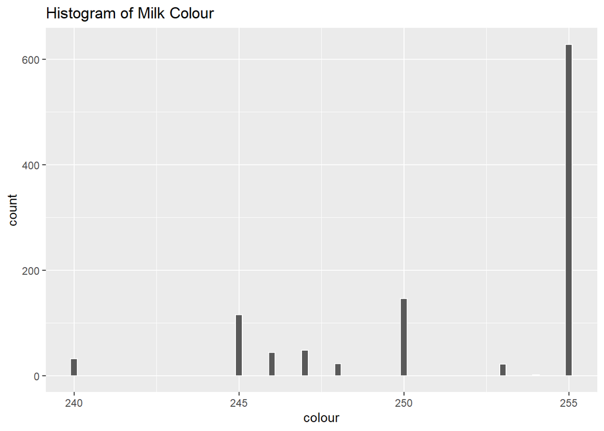

```r
milk %>%
  ggplot(aes(colour))+
  geom_histogram(binwidth = 0.2, colour = 'white')+
  labs(title = 'Histogram of Milk Colour')
```

From the histogram we can see that most milk samples are white color. A few milk samples are light yellow and smoke white.

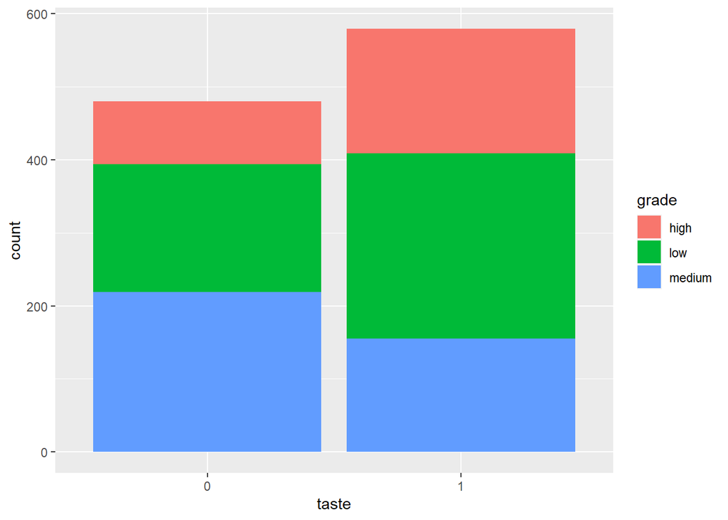

```r
milk %>%
  ggplot(aes(taste)) +
  geom_bar(aes(fill = grade))
```